# Statistical inference with the GSS data

## Setup

### Load packages

```r
library(ggplot2)
library(dplyr)
library(statsr)
```

### Load data

```r
load("gss.Rdata")
```

## Part 1: Data

The target population of the GSS is adults (18+) living in households in the United States. The GSS sample is drawn using an area probability design that randomly selects respondents in households across the United States to take part in the survey. Respondents that become part of the GSS sample are from a mix of urban, suburban, and rural geographic areas. Participation in the study is strictly voluntary. However, because only about a few thousand respondents are interviewed in the main study, every respondent selected is very important to the results. (https://en.wikipedia.org/wiki/General_Social_Survey)  
**Generalizability** Since the samples taken were random, we can generalize our results to the entire US population.  
**Causation** There was no experimental design used in the survey; this data is just observational. Therefore we can not show causation in our results.

## Part 2: Research question

**Has support for adult same sex relations increased over years since 1972?**

Same sex relationships have been a controversial topic for so long. And in recent years, same sex couples have had landmark decisions go their way, like legalisation of same sex marriages in many American states. This analysis is about finding out if there has been a shift in opinion of majority of US residents about this topic.

## Part 3: Exploratory data analysis

Our variables of interest for the research question are *homosex* and *year*. Lets create a subset of the *gss* with just these variables.

```r
myGss <- gss[,c('homosex','year')]
```

Lets do univariate analysis of these variables;

### homosex

```r
#summary statistics
summary(myGss$homosex)
```

```
##     Always Wrong Almst Always Wrg  Sometimes Wrong Not Wrong At All
##            21601             1581             2243             7282
##            Other             NA's
##               82            24272
```

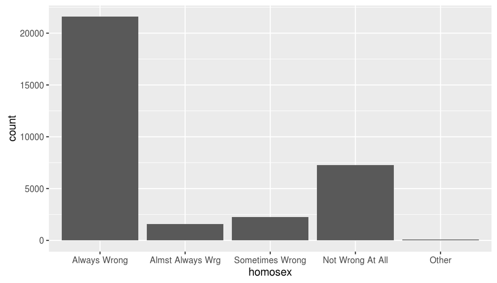

```r
#histogram of homosex
ggplot(na.omit(myGss), aes(x=homosex)) + geom_bar()
```

Cumulatively, the answer “always wrong” has been recorded the most followed by “not wrong at all”. Two very differing opinions.

### year

The next variable of interest is *year*, which is recorded as numerical but we will coarse it into a categorical variable and use it to see if opinion has changed over time.

```r
#nature of the variable
str(myGss$year)
```

```
##  int [1:57061] 1972 1972 1972 1972 1972 1972 1972 1972 1972 1972 ...
```

```r
#summary of years
summary(myGss$year)
```

```
##    Min. 1st Qu.  Median    Mean 3rd Qu.    Max.
##    1972    1983    1993    1992    2002    2012
```

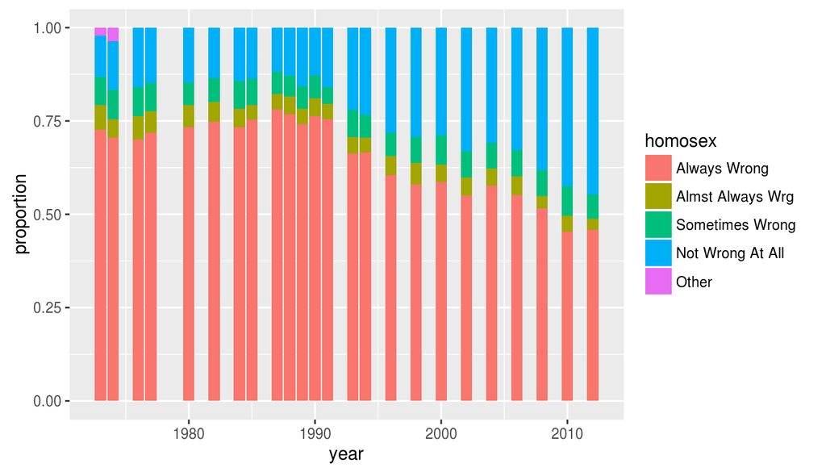

```r
#proportion of each answer to question for different years
ggplot(na.omit(myGss), aes(x = year, fill = homosex)) + geom_bar(position = 'fill') + ylab('proportion')
```

We can see an increase in prominence for the answer “not wrong at all” from 1972 to recent years. Is this increase significant though? Lets find out!

## Part 4: Inference

We are going to test if the proportion of people that said ‘not wrong at all’ has increased since 1973(there is no data for 1972). Since there is a general increase of this proportion since 1973 as seen in the graph above, let us use 1973 and 2012 as the populations of interest.  
**NB**: Whenever proportion is used ambiguously from here on, it refers to proportion of people that said ‘not wrong at all’ to the question on same sex relations.

### Create new data

Our approach is best suited for a two by two contigency table of people that said “not wrong at all” and those who did not say that, in the years 1973 and 2012. Lets create a new dataframe for this

```r
#add new variable homosex2 to new datafame myNewGss
myNewGss <- myGss %>%
  mutate(homosex2 = ifelse(homosex == 'Not Wrong At All', 'Not Wrong At All', 'Wrong'))
```

```r
#structure of myNewGss
str(myNewGss)
```

```
## 'data.frame':    57061 obs. of  3 variables:
##  $ homosex : Factor w/ 5 levels "Always Wrong",..: NA NA NA NA NA NA NA NA NA NA ...
##  $ year    : int  1972 1972 1972 1972 1972 1972 1972 1972 1972 1972 ...
##  $ homosex2: chr  NA NA NA NA ...
```

```r
#remove original homosex column and leave homosex2
myNewGss <- myNewGss[,2:3]
#turn homosex2 into factor data type
myNewGss$homosex2 <- as.factor(myNewGss$homosex2)
#rename homosex2 to homosex
names(myNewGss) <- c('year','homosex')
#remove missing values and keep only 1973 and 2012
myNewGss <- myNewGss%>%
  filter(!is.na(homosex))%>%
  filter(year==1973 | year==2012)
#structure of myNewGss
str(myNewGss)
```

```
## 'data.frame':    2687 obs. of  2 variables:
##  $ year   : int  1973 1973 1973 1973 1973 1973 1973 1973 1973 1973 ...
##  $ homosex: Factor w/ 2 levels "Not Wrong At All",..: 2 2 2 2 2 2 2 1 2 2 ...
```

### Confidence intervals

1. Respondents were randomly sampled, and sample size is less than 10% of US population therefore sample observations are independent
2. Success-failure conditions

   ```r
   #number of respondents for each answer in 1973
   myNewGss%>%
     filter(year==1973)%>%
     group_by(homosex)%>%
     summarise(count = n())
   ```

   ```
   ## Source: local data frame [2 x 2]
   ##
   ##            homosex count
   ##             <fctr> <int>
   ## 1 Not Wrong At All   159
   ## 2            Wrong  1289
   ```

   ```r
   #number of respondents for each answer in 2012
   myNewGss%>%
     filter(year==2012)%>%
     group_by(homosex)%>%
     summarise(count = n())
   ```

   ```
   ## Source: local data frame [2 x 2]
   ##
   ##            homosex count
   ##             <fctr> <int>
   ## 1 Not Wrong At All   553
   ## 2            Wrong   686
   ```

   Number of successes (said ‘Not wrong at all’) and number of failures (said otherwise) are both above 10.

Since these conditions are met, the sample distributions are nearly normal.

We shall use the inference function to calculate the 95% confidence interval of the proportion of people that said ‘not wrong at all’ in entire the US population.

```r
#For 1973
myGss1973 <-myNewGss%>%
  filter(year==1973)

inference(y = homosex, data = myGss1973, type = 'ci', statistic = 'proportion', success = 'Not Wrong At All', method = 'theoretical')
```

```
## Single categorical variable, success: Not Wrong At All
## n = 1448, p-hat = 0.1098
## 95% CI: (0.0937 , 0.1259)
```

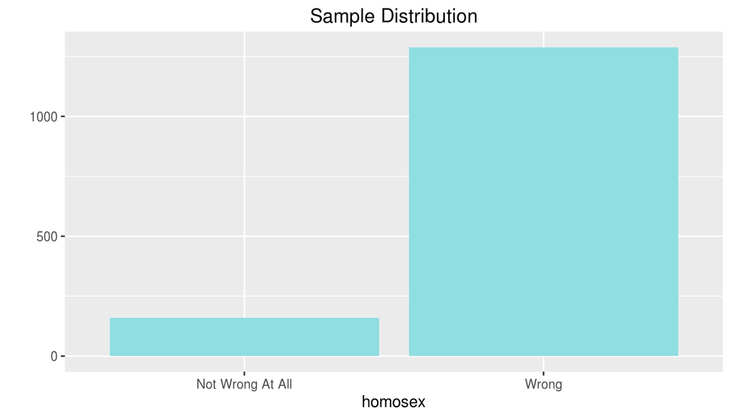

We are 95% confident that the proportion of people in the US that answered “Not wrong at all” to the question of what they think about same sex relations in 1973 is between 9.37% to 12.59%

```r
#For 2012
myGss2012 <- myNewGss%>%
  filter(year==2012)

inference(y = homosex, data = myGss2012, type = 'ci', statistic = 'proportion', success = 'Not Wrong At All', method = 'theoretical')
```

```
## Single categorical variable, success: Not Wrong At All
## n = 1239, p-hat = 0.4463
## 95% CI: (0.4186 , 0.474)
```

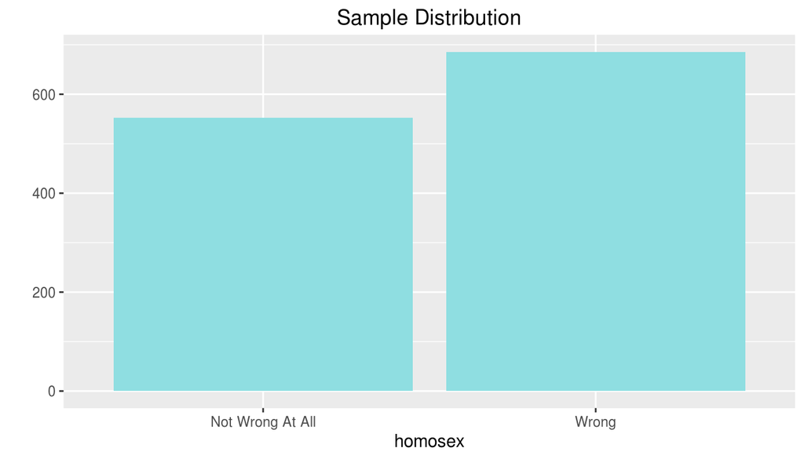

We are 95% confident that the proportion of people in the US that answered “Not wrong at all” to the question of what they think about same sex relations in 2012 is between 41.86% and 47.4%  
We can infer at least a minimum difference in proportions of (41.86 - 12.59) = 29.27% in the entire US population between 1973 and 2012 of people that said same sex relations were not wrong at all.

### Hypothesis Test

This will be a theoretical approach to testing difference of two proportions.  
Our null hypothesis is that there has not been a change in proportion of people that said ‘not wrong at all’ to same sex relations in the entire nation in 1973 and 2012.

$p_{1973}$-$p_{2012}$ = 0

The alternative hypothesis is that there has been an increase in proportions between 1973 and 2012.

$p_{1973}$-$p_{2012}$ < 0

Can we use the normal model to analyse this survey?

1. Firstly, because observations from both samples were random and less than 10% of the population, we will treat them as independent.
2. Secondly, To check the success-failure condition, we must use the pooled proportion

   $\widehat{p}$ = $\frac{Number Of People who Said Not Wrong At All}{Total Number of People}$

   ```r
   myNewGss%>%
     group_by(homosex)%>%
     summarise(count = n())
   ```

   ```
   ## Source: local data frame [2 x 2]
   ##
   ##            homosex count
   ##             <fctr> <int>
   ## 1 Not Wrong At All   712
   ## 2            Wrong  1975
   ```

   $\widehat{p}$ = $\frac{712}{2687}$

   $\widehat{p}$ = 0.2649795

   **Success - Failure check**

   ```r
   myNewGss%>%
     filter(year==2012)%>%
     summarise(count = n())
   ```

   ```
   ##   count
   ## 1  1239
   ```

   ```r
   myNewGss%>%
     filter(year==1973)%>%
     summarise(count = n())
   ```

   ```
   ##   count
   ## 1  1448
   ```

   $\widehat{p}$ x $n_{1973}$ = 0.2649795 x 1448 = 383.6903 $\widehat{p}$ x $n_{2012}$ = 0.2649795 x 1239 = 328.3096  
   (1 - $\widehat{p}$ x $n_{1973}$) = 0.7350205 x 1448 = 1064.31 (1 - $\widehat{p}$ x $n_{2012}$) = 0.7350205 x 1239 = 910.6904

   The success-failure condition is satisfied since all values are at least 10, and we can safely apply the normal model.

Using the inference function to test the hypothesis at 0.05 significance level;

$H_0$: $p_{1973}$ - $p_{2012}$ = 0

$H_A$: $p_{1973}$ - $p_{2012}$ < 0

```r
inference(y = homosex, x = year, data = myNewGss, statistic = 'proportion', type = 'ht', null = 0, alternative = 'less', method = 'theoretical', success = 'Not Wrong At All' )
```

```
## Response variable: categorical (2 levels, success: Not Wrong At All)
## Explanatory variable: categorical (2 levels)
## n_1973 = 1448, p_hat_1973 = 0.1098
## n_2012 = 1239, p_hat_2012 = 0.4463
## H0: p_1973 =  p_2012
## HA: p_1973 < p_2012
## z = -19.7035
## p_value = < 0.0001
```

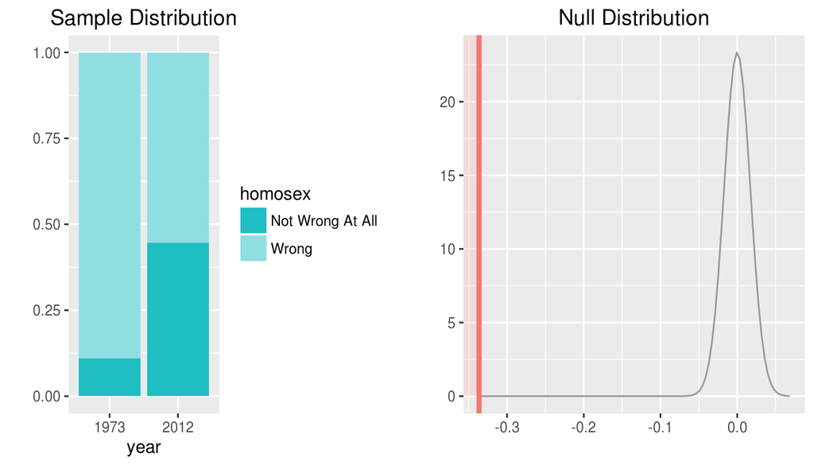

Using the normal model for this test statistic, we identify the lower tail area to be 0.0001 which less than 0.05, therefore we reject the null hypothesis.  
That is, we have statistically significant evidence that the proportion of people with the opinion that same sex relations among adults is not wrong at all has increased since 1973.

### Conclusion

The hypothesis test and confidence intervals agree in that there was a clear difference in proportions between 1973 and 2012.  
Given the large number of missing values, it seems many people were not willing to answer the question. The results would be more precise if we had more observations to work with. Maybe more anonymous ways of answering this question can be made available in future surveys.